# 7. Practice_Project--Matplotlib _ Seaborn - CSV based Data Visualization

## Practice Project - Matplotlib based : CSV based Data Visualization

### Table of Contents

[output not shown]

### Problem Statement:

- Activity: Students are provided with this Dataset 'students.csv'

  ```
      In this data set you need to visualize whether we have more male or female students in school.<br>
  ```

- Activity: Get Correlation Matrix for 'students.csv' data.

## Introduction

1. Data Visualization is the process of presenting data in the form of graphs or charts.
2. It helps to understand large and complex amounts of data very easily.
3. It allows us to identify new trends and patterns very easily.

Matploptib is a low-level library of Python which is used for data visualization, This library is built on the top of NumPy arrays and consist of several plots like line chart, bar chart, histogram, etc.These various plots we can be visualized using Pyplot

### Importing Matplotlib

```python
import matplotlib.pyplot as plt
```

### Initializing the data

```python
x = [10, 20, 30, 40]
y = [20, 25, 35, 55]
```

### plotting the data

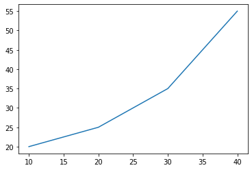

```python
plt.plot(x, y)

plt.show()
```

### Adding title to the plot

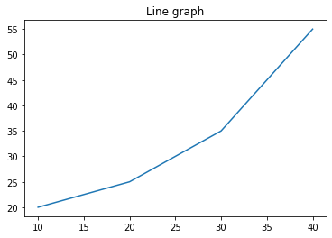

```python
plt.plot(x, y)

plt.title("Line graph")

plt.show()
```

### Adding label on the X - Axis and Y - Axis

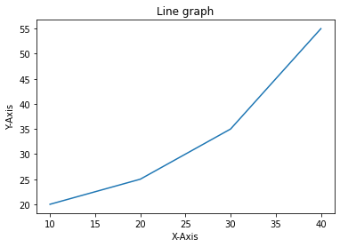

```python
plt.plot(x, y)

plt.title("Line graph")

plt.xlabel('X-Axis')

plt.ylabel('Y-Axis')
```

### Activity

Create Two Variables Age and Height Start with initial age 5yrs plot a line graph of your age with Height Give it a Title and add X AND Y Labels

```python
age = [5,6,7,8,9,10,11,12,13]
Height = [3.4,4,4.2,4.5,4.8,5.1,5.1,5.2,5.4]
```

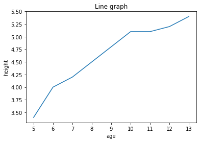

```python
plt.plot(age, Height)

plt.title("Line graph")

plt.xlabel('age')

plt.ylabel('height')
```

### Working on Actual Data

```python
import pandas as pd
```

```python
data = pd.read_csv('tips.csv')
```

```python
data.head()
```

|  | total_bill | tip | sex | smoker | day | time | size |
| --- | --- | --- | --- | --- | --- | --- | --- |
| 0 | 16.99 | 1.01 | Female | No | Sun | Dinner | 2 |
| 1 | 10.34 | 1.66 | Male | No | Sun | Dinner | 3 |
| 2 | 21.01 | 3.50 | Male | No | Sun | Dinner | 3 |
| 3 | 23.68 | 3.31 | Male | No | Sun | Dinner | 2 |
| 4 | 24.59 | 3.61 | Female | No | Sun | Dinner | 4 |

### Understanding Day Wise Revenue

```python
x = data['day']
y = data['total_bill']
```

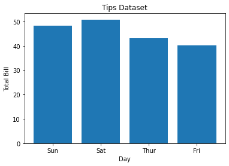

```python
# plotting the data
plt.bar(x, y)

# Adding title to the plot
plt.title("Tips Dataset")

# Adding label on the y-axis
plt.ylabel('Total Bill')

# Adding label on the x-axis
plt.xlabel('Day')

plt.show()
```

### Understanding the data and analyse whether More customer visit for lunch or Dinner

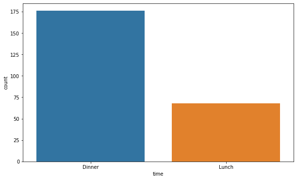

```python
import seaborn as sns
fig = plt.figure(figsize=(10,6))
sns.countplot(data['time'],data=data)
plt.show()
```

```python
head_count=data['time'].value_counts()
print(head_count)
```

```
Dinner    176
Lunch      68
Name: time, dtype: int64
```

### Activity: Now Students You Have this Dataset students.csv, in this data set you need to visualize whether we have more male or female students in school.

```python
df = pd.read_csv('students.csv')
```

```python
df.head()
```

|  | Gr.No | school | sex | age | guardian |
| --- | --- | --- | --- | --- | --- |
| 0 | 1000 | GP | F | 18 | mother |
| 1 | 1001 | GP | F | 17 | father |
| 2 | 1002 | GP | F | 15 | mother |
| 3 | 1003 | GP | F | 15 | mother |
| 4 | 1004 | GP | F | 16 | father |

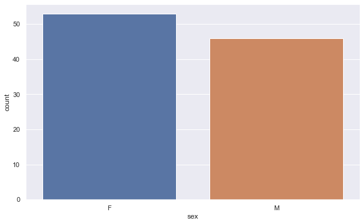

```python
import seaborn as sns
fig = plt.figure(figsize=(10,6))
sns.countplot(df['sex'],data=df)
plt.show()
```

```python
head_count=df['sex'].value_counts()
print(head_count)
```

```
F    53
M    46
Name: sex, dtype: int64
```

### Understanding correlation

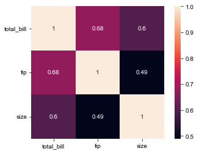

```python
import seaborn as sns
corr = data.corr()
sns.heatmap(corr, annot=True, square=True)
plt.yticks(rotation=0)
sns.set(rc = {'figure.figsize':(150,80)}) #run commands
plt.show()
```

### Activity: get Correlation Matrix for students.csv data

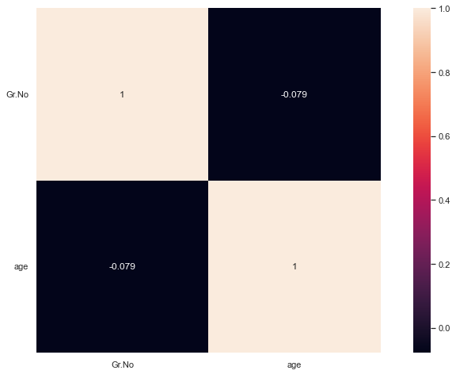

```python
import seaborn as sns
corr = df.corr()
sns.heatmap(corr, annot=True, square=True)
plt.yticks(rotation=0)
sns.set(rc = {'figure.figsize':(100,60)})
plt.show()
```